# DATA612 Project 4 | Accuracy and Beyond

Javern Wilson

June 29, 2019

## Dating Recommender System

Some comments about the dataset:

1. There are 135,359 users and 168,791 profiles with 17,359,346 ratings.
2. userId is the user who provided rating.
3. profileID is the user who has been rated.
4. Ratings are on a scale of 1 - 10 where 10 is the highest.
5. Only users who provide at least 20 ratings were included. User gender information is also available with idenfiers (M, F, U-Unknown).

## Libraries

```r
library(recommenderlab)
library(tidyverse)
library(kableExtra)
```

## Data Pre-processing

Import files

The files are too large to upload to my github even when zipped so you can find it [here](http://www.occamslab.com/petricek/data/).

```r
d_ratings <- read.csv("C:/Users/Javern/Documents/Data Science MS/DATA612/libimseti-complete/libimseti/ratings.dat", header = F, sep = ",")
colnames(d_ratings) <- c("userId", "profileId", "rating")
d_ratings$userId <- as.factor(d_ratings$userId)
d_ratings$profileId <- as.factor(d_ratings$profileId)
gender <- read.csv("C:/Users/Javern/Documents/Data Science MS/DATA612/libimseti-complete/libimseti/gender.dat", header = F, sep = ",")
colnames(gender) <- c("userId", "type")
gender$userId <- as.factor(gender$userId)
```

## EDA

### Preview of datasets

```r
head(d_ratings); head(gender)
```

|  | userId | profileId | rating |
| --- | --- | --- | --- |
| 1 | 1 | 133 | 8 |
| 2 | 1 | 720 | 6 |
| 3 | 1 | 971 | 10 |
| 4 | 1 | 1095 | 7 |
| 5 | 1 | 1616 | 10 |
| 6 | 1 | 1978 | 7 |

|  | userId | type |
| --- | --- | --- |
| 1 | 1 | F |
| 2 | 2 | F |
| 3 | 3 | U |
| 4 | 4 | F |
| 5 | 5 | F |
| 6 | 6 | F |

### Top 10 users who provided the most ratings

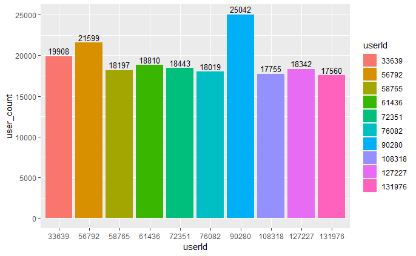

```r
d_ratings %>%
  group_by(userId)%>%
  summarise(user_count = length(userId)) %>%
  top_n(10) %>%
  ggplot(aes(userId, user_count, fill = userId)) + geom_bar(stat = "identity") + geom_text(aes(label=user_count), vjust=-0.3, size=3.5)
```

### Top rated profiles

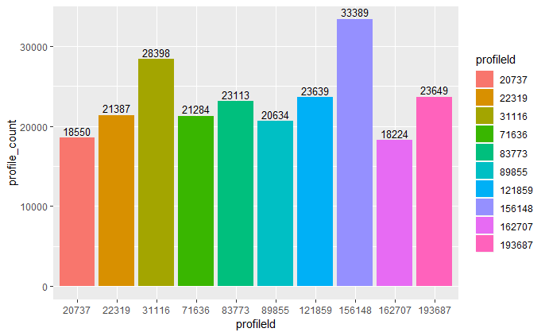

```r
d_ratings %>%
  group_by(profileId) %>%
  summarise(profile_count = length(profileId)) %>%
  top_n(10) -> topprofiles
  ggplot(topprofiles, aes(profileId, profile_count, fill = profileId)) +
    geom_bar(stat = "identity") +
    geom_text(aes(label=profile_count), vjust=-0.3, size=3.5)
```

### How scores are distributed

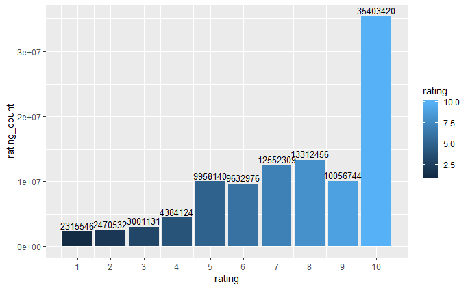

```r
d_ratings %>%
   group_by(rating)%>%
   summarise(rating_count = sum(rating)) %>%
   ggplot(aes(rating, rating_count, fill = rating)) + geom_bar(stat = "identity") +   scale_x_continuous(breaks = seq(1, 10)) + geom_text(aes(label=rating_count), vjust=-0.3, size=3.5)
```

### Gender ratio

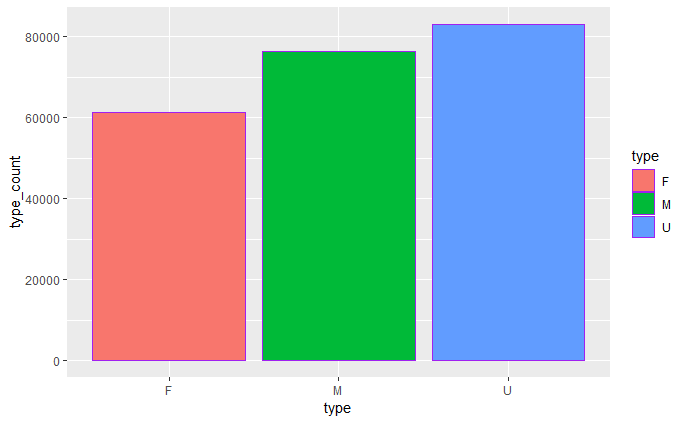

```r
gender %>%
  group_by(type) %>%
  summarise(type_count = length(type)) %>%
  ggplot(aes(type, type_count, fill = type)) + geom_bar(stat = "identity", color = "purple")
```

```r
NA
```

## Dating Matrix

As we move forward in the analysis, the ratings dataframe will be converted into a matrix to build and evaluate the recommendation systems.

```r
dmatrix <- as(d_ratings, "realRatingMatrix")
dmatrix
```

```
135359 x 168791 rating matrix of class realRatingMatrix with 17359346 ratings.
```

Dimensions of the matrix

```r
dim(dmatrix@data)
```

```
[1] 135359 168791
```

Size of matrix data

```r
object.size(dmatrix)
```

```
228455328 bytes
```

About 228 MB

The file is large so we’ll cut down on the number of attributes.

```r
# users who rated at least 500 profiles
# profiles that are rated at least 1000 times
dmatrix <- dmatrix[rowCounts(dmatrix) > 500, colCounts(dmatrix) > 800]
dmatrix
```

```
3894 x 3391 rating matrix of class realRatingMatrix with 1134236 ratings.
```

#### Average Profile Ratings

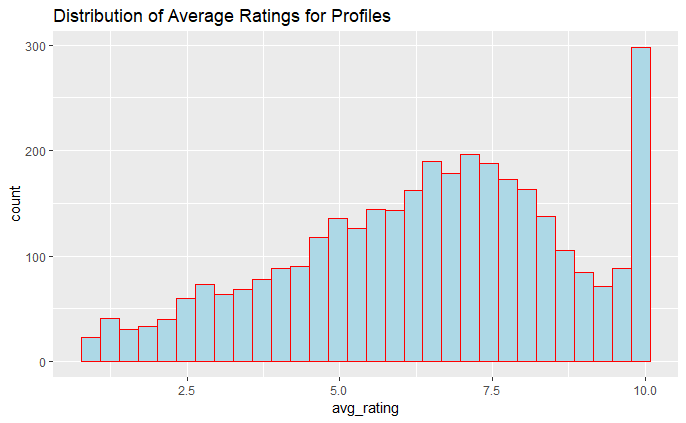

```r
avg_profile_ratings <- data.frame("avg_rating" = colMeans(dmatrix)) %>%
  ggplot(aes(x = avg_rating)) +
  geom_histogram(color = "red", fill = "lightblue") +
  ggtitle("Distribution of Average Ratings for Profiles")
avg_profile_ratings
```

#### How similar are the first 300 users?

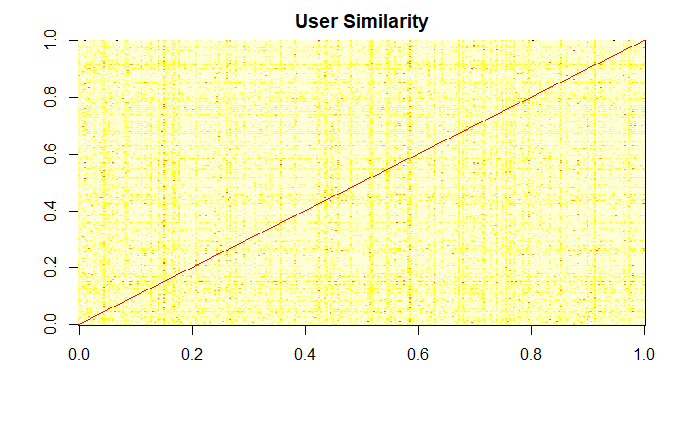

```r
sim <- similarity(dmatrix[1:300, ], method = "cosine", which = "users")
image(as.matrix(sim), main = "User Similarity")
```

#### How similar are the first 300 profiles?

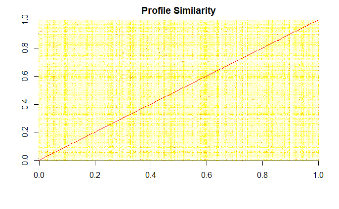

```r
sim2 <- similarity(dmatrix[, 1:300], method = "cosine", which = "items")
image(as.matrix(sim2), main = "Profile Similarity")
```

## Training and Test Sets

```r
#min(rowCounts(dmatrix))= 6 so we can keep 5 items per user
dmat_eval <- evaluationScheme(data = dmatrix, method = "split", train = 0.9, given = 5, goodRating = 5, k = 4)
dmat_eval
```

```
Evaluation scheme with 5 items given
Method: split with 4 run(s).
Training set proportion: 0.900
Good ratings: >=5.000000
Data set: 3894 x 3391 rating matrix of class realRatingMatrix with 1134236 ratings.
```

## Compare Recommender System Algorithms

```r
algorithms <- list(
  IBCF = list(name = "IBCF", param = list(method = "cosine")),
  UBCF = list(name = "UBCF", param = list(method = "cosine")),
  SVD = list(name = "SVD", param = list(k = 30)),
  POPULAR = list(name = "POPULAR", param = NULL), #serendipity
  RANDOM = list(name = "RANDOM", param = NULL)
)
```

Test the models by varying the number of profiles to recommend.

```r
# run algorithms, predict next n profile
eval_results <- evaluate(dmat_eval, algorithms, type = "topNList", n = c(1, 3, 5, 10, 15, 20))
```

```
IBCF run fold/sample [model time/prediction time]
     1  [497.85sec/0.43sec]
     2  [493.34sec/0.41sec]
     3  [492.62sec/0.29sec]
     4  [495.82sec/0.2sec]
UBCF run fold/sample [model time/prediction time]
     1  [0.17sec/41.13sec]
     2  [0.17sec/42.32sec]
     3  [0.16sec/39.14sec]
     4  [0.23sec/40.22sec]
SVD run fold/sample [model time/prediction time]
     1  [3.33sec/1.24sec]
     2  [3.31sec/1.13sec]
     3  [3.58sec/1.27sec]
     4  [3.45sec/1.17sec]
POPULAR run fold/sample [model time/prediction time]
     1  [0.19sec/4.05sec]
     2  [0.19sec/4.03sec]
     3  [0.22sec/3.88sec]
     4  [0.2sec/3.89sec]
RANDOM run fold/sample [model time/prediction time]
     1  [0sec/1.28sec]
     2  [0sec/1.11sec]
     3  [0sec/1.28sec]
     4  [0sec/1.28sec]
```

```r
averages <- avg(eval_results)
```

#### Results

TP - True Positive FP - False Positive FN - False Negative TN - True Negative

```r
kable(averages$IBCF) %>% kable_styling(bootstrap_options = c("striped", "bordered"), full_width = F, font_size = 11) %>% add_header_above(c(" ", "IBCF" = 8))
```

|  | IBCF TP | IBCF FP | IBCF FN | IBCF TN | IBCF precision | IBCF recall | IBCF TPR | IBCF FPR |
| --- | --- | --- | --- | --- | --- | --- | --- | --- |
| 1 | 0.0179487 | 0.975641 | 222.5199 | 3162.487 | 0.0180648 | 0.0000925 | 0.0000925 | 0.0003090 |
| 3 | 0.0596154 | 2.882051 | 222.4782 | 3160.580 | 0.0200050 | 0.0002740 | 0.0002740 | 0.0009123 |
| 5 | 0.0967949 | 4.723718 | 222.4410 | 3158.738 | 0.0195725 | 0.0004463 | 0.0004463 | 0.0014955 |
| 10 | 0.1794872 | 9.063462 | 222.3583 | 3154.399 | 0.0184412 | 0.0007813 | 0.0007813 | 0.0028689 |
| 15 | 0.2717949 | 13.057692 | 222.2660 | 3150.404 | 0.0190787 | 0.0011761 | 0.0011761 | 0.0041339 |
| 20 | 0.3391026 | 16.832051 | 222.1987 | 3146.630 | 0.0182538 | 0.0014670 | 0.0014670 | 0.0053300 |

```r
kable(averages$UBCF) %>% kable_styling(bootstrap_options = c("striped", "bordered"), full_width = F, font_size = 11) %>% add_header_above(c(" ", "UBCF" = 8))
```

|  | UBCF TP | UBCF FP | UBCF FN | UBCF TN | UBCF precision | UBCF recall | UBCF TPR | UBCF FPR |
| --- | --- | --- | --- | --- | --- | --- | --- | --- |
| 1 | 0.449359 | 0.5487179 | 222.0885 | 3162.913 | 0.4502025 | 0.0024331 | 0.0024331 | 0.0001721 |
| 3 | 1.327564 | 1.6666667 | 221.2103 | 3161.796 | 0.4433765 | 0.0070320 | 0.0070320 | 0.0005221 |
| 5 | 2.157692 | 2.8326923 | 220.3801 | 3160.629 | 0.4323913 | 0.0113597 | 0.0113597 | 0.0008872 |
| 10 | 4.025000 | 5.9557692 | 218.5128 | 3157.506 | 0.4033029 | 0.0208295 | 0.0208295 | 0.0018655 |
| 15 | 5.716667 | 9.2544872 | 216.8212 | 3154.208 | 0.3818708 | 0.0289989 | 0.0289989 | 0.0028990 |
| 20 | 7.313461 | 12.6480769 | 215.2244 | 3150.814 | 0.3664033 | 0.0366339 | 0.0366339 | 0.0039625 |

```r
kable(averages$SVD) %>% kable_styling(bootstrap_options = c("striped", "bordered"), full_width = F, font_size = 11) %>% add_header_above(c(" ", "SVD" = 8))
```

|  | SVD TP | SVD FP | SVD FN | SVD TN | SVD precision | SVD recall | SVD TPR | SVD FPR |
| --- | --- | --- | --- | --- | --- | --- | --- | --- |
| 1 | 0.2500000 | 0.750000 | 222.2878 | 3162.712 | 0.2500000 | 0.0014511 | 0.0014511 | 0.0002370 |
| 3 | 0.7108974 | 2.289103 | 221.8269 | 3161.173 | 0.2369658 | 0.0039949 | 0.0039949 | 0.0007227 |
| 5 | 1.1538462 | 3.846154 | 221.3840 | 3159.616 | 0.2307692 | 0.0064196 | 0.0064196 | 0.0012140 |
| 10 | 2.2198718 | 7.780128 | 220.3179 | 3155.682 | 0.2219872 | 0.0124932 | 0.0124932 | 0.0024563 |
| 15 | 3.2980769 | 11.701923 | 219.2397 | 3151.760 | 0.2198718 | 0.0183008 | 0.0183008 | 0.0036935 |
| 20 | 4.3525641 | 15.647436 | 218.1853 | 3147.815 | 0.2176282 | 0.0239089 | 0.0239089 | 0.0049379 |

```r
kable(averages$POPULAR) %>% kable_styling(bootstrap_options = c("striped", "bordered"), full_width = F, font_size = 11) %>% add_header_above(c(" ", "POPULAR" = 8))
```

|  | POPULAR TP | POPULAR FP | POPULAR FN | POPULAR TN | POPULAR precision | POPULAR recall | POPULAR TPR | POPULAR FPR |
| --- | --- | --- | --- | --- | --- | --- | --- | --- |
| 1 | 0.4057692 | 0.5942308 | 222.1321 | 3162.868 | 0.4057692 | 0.0018452 | 0.0018452 | 0.0001856 |
| 3 | 1.2275641 | 1.7724359 | 221.3103 | 3161.690 | 0.4091880 | 0.0058259 | 0.0058259 | 0.0005546 |
| 5 | 2.0128205 | 2.9871795 | 220.5250 | 3160.475 | 0.4025641 | 0.0092910 | 0.0092910 | 0.0009331 |
| 10 | 3.7782051 | 6.2217949 | 218.7596 | 3157.240 | 0.3778205 | 0.0175165 | 0.0175165 | 0.0019462 |
| 15 | 5.4551282 | 9.5448718 | 217.0827 | 3153.917 | 0.3636752 | 0.0253210 | 0.0253210 | 0.0029850 |
| 20 | 7.1230769 | 12.8769231 | 215.4147 | 3150.585 | 0.3561538 | 0.0322594 | 0.0322594 | 0.0040242 |

```r
kable(averages$RANDOM) %>% kable_styling(bootstrap_options = c("striped", "bordered"), full_width = F, font_size = 11) %>% add_header_above(c(" ", "RANDOM" = 8))
```

|  | RANDOM TP | RANDOM FP | RANDOM FN | RANDOM TN | RANDOM precision | RANDOM recall | RANDOM TPR | RANDOM FPR |
| --- | --- | --- | --- | --- | --- | --- | --- | --- |
| 1 | 0.0692308 | 0.9307692 | 222.4686 | 3162.531 | 0.0692308 | 0.0003498 | 0.0003498 | 0.0002944 |
| 3 | 0.2198718 | 2.7801282 | 222.3179 | 3160.682 | 0.0732906 | 0.0010129 | 0.0010129 | 0.0008787 |
| 5 | 0.3660256 | 4.6339744 | 222.1718 | 3158.828 | 0.0732051 | 0.0016633 | 0.0016633 | 0.0014648 |
| 10 | 0.7179487 | 9.2820513 | 221.8199 | 3154.180 | 0.0717949 | 0.0033660 | 0.0033660 | 0.0029348 |
| 15 | 1.0525641 | 13.9474359 | 221.4853 | 3149.515 | 0.0701709 | 0.0049277 | 0.0049277 | 0.0044104 |
| 20 | 1.4205128 | 18.5794872 | 221.1173 | 3144.883 | 0.0710256 | 0.0066586 | 0.0066586 | 0.0058743 |

#### ROC curve

The ROC curve is created by plotting the true positive rate against the false positive rate. The closer an ROC curve is to the upper left corner, the more efficient is the test.

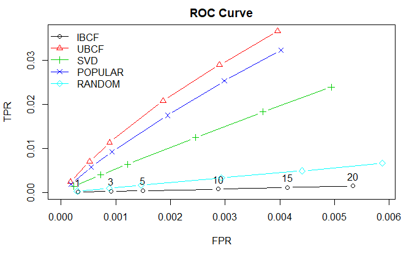

```r
plot(eval_results, annotate = T, legend="topleft")
title("ROC Curve")
```

Based on the graph visualization above, the UBCF is better than the others.

#### Precision-Recall

Precision expresses the proportion of the data points our model says was relevant and are actually were relevant. Calculated as: **TP / (TP + FP)**

Recall expresses the ability to find all relevant instances in a dataset or the model’s ability to find all the data points of interest in a dataset. **TP / (TP + FN)**

The closer the curve or line is to the top right, the better the performance of the algorithm.

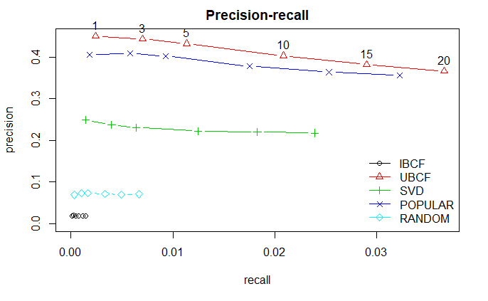

```r
# precision / recall
plot(eval_results, "prec/rec", annotate = 2)
title("Precision-recall")
```

User Based model is still better than the other algorithms.

```r
#Predict top-N recommendation lists
eval_results2 <- evaluate(dmat_eval, algorithms, type = "ratings")
```

```
IBCF run fold/sample [model time/prediction time]
     1  [493.46sec/0.12sec]
     2  [505.67sec/0.14sec]
     3  [500.72sec/0.12sec]
     4  [499.53sec/0.14sec]
UBCF run fold/sample [model time/prediction time]
     1  [0.17sec/41.48sec]
     2  [0.17sec/40.88sec]
     3  [0.19sec/39.89sec]
     4  [0.17sec/41.02sec]
SVD run fold/sample [model time/prediction time]
     1  [3.41sec/0.93sec]
     2  [3.33sec/0.74sec]
     3  [3.77sec/0.7sec]
     4  [3.37sec/0.63sec]
POPULAR run fold/sample [model time/prediction time]
     1  [0.2sec/0.44sec]
     2  [0.35sec/0.36sec]
     3  [0.19sec/0.44sec]
     4  [0.19sec/0.41sec]
RANDOM run fold/sample [model time/prediction time]
     1  [0.01sec/0.74sec]
     2  [0sec/0.87sec]
     3  [0sec/0.88sec]
     4  [0.01sec/0.79sec]
```

```r
avg(eval_results2)
```

```
$`IBCF`
        RMSE      MSE      MAE
res 2.487833 6.196339 1.179454

$UBCF
        RMSE     MSE      MAE
res 2.784005 7.75109 2.235006

$SVD
        RMSE     MSE      MAE
res 2.986838 8.92139 2.420337

$POPULAR
        RMSE      MSE      MAE
res 2.187636 4.786568 1.673285

$RANDOM
        RMSE     MSE      MAE
res 3.707756 13.7477 2.933583
```

#### Online Evaluation

As noted, offline evaluations use precompiled offline datasets from which data was removed hence evaluations are used to analyze the algorthims’ ablity to predict missing data. On the other hand, in online evaluations, recommendations are shown to real users of the system during their session and so users do not rate recommendations but the recommender system observes how often a user accepts a recommendation. One metric that could be used to evaluate online evaluation is **click-through rate (CTR)**. This measures the ratio of clicks to the number of recommendation lists provided. So for instance if the recommender recommends 1000 profiles and the user clicks only 5 then the CTR would be 0.5%.

## References

https://towardsdatascience.com/beyond-accuracy-precision-and-recall-3da06bea9f6c https://acutecaretesting.org/en/articles/roc-curves-what-are-they-and-how-are-they-used https://pdfs.semanticscholar.org/94c2/00cec1e2f9547ea6063e08019f72895bfba8.pdf https://link.springer.com/article/10.1007/s13042-017-0762-9